# Homework 8

*Enter your name and EID here*

**This homework is due on April 19, 2021 at 11:00pm. Please submit as a pdf file on Canvas.**

In this homework, we will work with two datasets, `US_counties` and `US_census`. The dataset `US_counties` contains the geometry of each county in the US and thus can be used for drawing maps. The dataset `US_census` contains numerous pieces of information about US counties obtained from the US census. Both datasets have a column `FIPS` which can be used to uniquely identify each county in each dataset.

```r
# data preparation
US_counties <- readRDS(url("https://wilkelab.org/SDS375/datasets/US_counties.rds")) %>%
  rename(FIPS = GEOID)

US_census <- read_csv(
  "https://wilkelab.org/SDS375/datasets/US_census.csv",
  col_types = cols(FIPS = "c")
)
```

**Problem 1: (6 pts)** Make a choropleth map of the percent home-ownership (column `home_ownership` in `US_census`) for all counties in the US. Choose an appropriate color scale and design for this plot. You may notice that there is one county in Alaska for which home-ownership data is not available. Write data analysis code to identify this county.

**Hints:**

1. Use `theme_void()` as your theme
2. You will have to join `US_counties` and `US_census`. Join them by the `FIPS` column.
3. To make nice percent labels, you can use `label = scales::label_percent(scale = 1)` in your color scale function.
4. To find rows with missing data, you may want to use the function `is.na()`.

Grade breakdown: 2pt for the plot, 2pt for the plot design, and 2pt for identifying the county in Alaska for which home ownership data is not available.

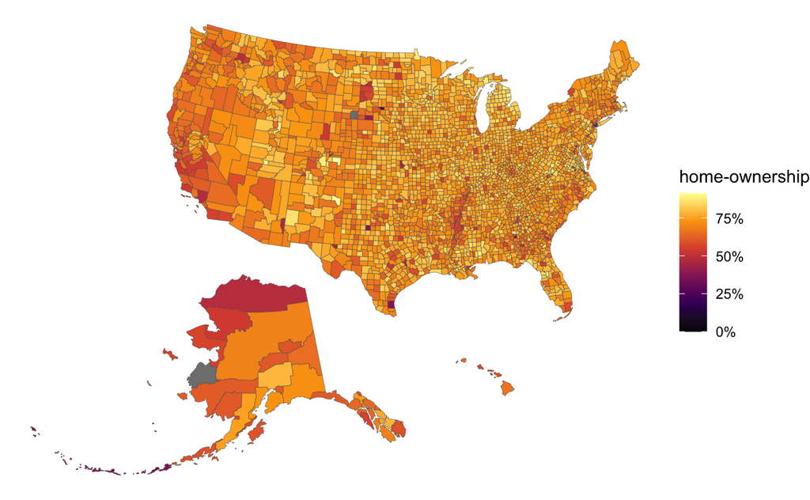

```r
# code to make the plot
US_counties %>%
  left_join(US_census, by = "FIPS") %>%
  ggplot() +
  geom_sf(aes(fill = home_ownership), size = 0.1) +
  scale_fill_viridis_c(
    name = "home-ownership",
    option = "B",
    label = scales::label_percent(scale = 1)
  ) +
  theme_void()
```

```r
# code to find the county with missing data
US_counties %>%
  left_join(US_census, by = "FIPS") %>%
  filter(state_code == "AK", is.na(home_ownership)) %>%
  pull(NAME)
```

```
## [1] Kusilvak
## 1910 Levels: Abbeville Acadia Accomack Ada Adair Adams Addison ... Ziebach
```

The county with missing data is called “Kusilvak”.

**Problem 2: (4 pts)** Make a choropleth map of the percent foreign born (column `foreign_born` in `US_census`) for the counties in Texas only. Apply a Texas-centric projection. Additionally, use a different color scale than you used for Problem 1 and use a theme that shows longitude and latitude (nearly any theme other than `theme_void()` will work).

Grade breakdown: 3pt for the plot, 1pt for the plot design

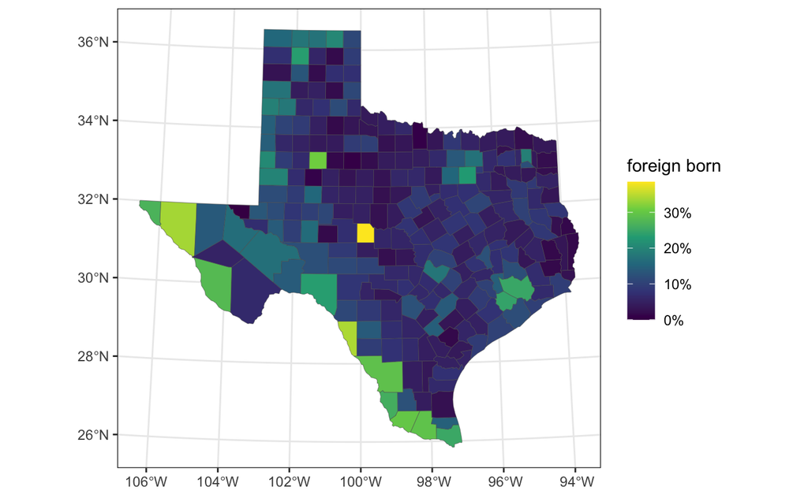

```r
US_counties %>%
  filter(state_code == "TX") %>%
  left_join(US_census, by = "FIPS") %>%
  ggplot() +
  geom_sf(aes(fill = foreign_born), size = 0.1) +
  scale_fill_viridis_c(
    name = "foreign born",
    label = scales::label_percent(scale = 1)
  ) +
  theme_bw() +
  coord_sf(
    # Texas Centric Albers Equal Area
    crs = 3083
  )
```